# **Review of Statistical Estimation**

**STA4173: Biostatistics**  
Spring 2025

## **Introduction**

- In this lecture, we will review estimation
  - Continuous variables
    - Mean
    - Median
    - Percentiles / quartiles
    - Variance and standard deviation
    - Interquartile range
  - Categorical variables
    - Count
    - Percentage
- We will also discuss exploring data graphically

## **R: Introduction**

- In this course, we will review formulas, but we will use R for computational purposes
  - Remember to refer to the lecture notes for specific code needed
  - Code is also available on this course’s GitHub repository
- You can install R and RStudio if you wish; both are free.
  - We have access to the [Posit Workbench](https://rstudio.hmcse.uwf.edu/) (“the server”) through HMCSE.
- I know that this is probably the first time you are seeing R (or any sort of programming).
  - That is why we have “R lab” time built in to our course.
  - Remember that I am not looking for perfection, but instead for competency.

## **Today’s Data: Palmer Penguins**

- Today we will be demonstrating the basics using the [Palmer Penguins](https://allisonhorst.github.io/palmerpenguins/) dataset, available through R.

```r
penguins <- palmerpenguins::penguins
```

| species | island | bill_length_mm | bill_depth_mm | flipper_length_mm | body_mass_g | sex | year |
| --- | --- | --- | --- | --- | --- | --- | --- |
| Adelie | Torgersen | 39.1 | 18.7 | 181 | 3750 | male | 2007 |
| Adelie | Torgersen | 39.5 | 17.4 | 186 | 3800 | female | 2007 |
| Adelie | Torgersen | 40.3 | 18.0 | 195 | 3250 | female | 2007 |
| Adelie | Torgersen | NA | NA | NA | NA | NA | 2007 |
| Adelie | Torgersen | 36.7 | 19.3 | 193 | 3450 | female | 2007 |
| Adelie | Torgersen | 39.3 | 20.6 | 190 | 3650 | male | 2007 |
| Adelie | Torgersen | 38.9 | 17.8 | 181 | 3625 | female | 2007 |
| Adelie | Torgersen | 39.2 | 19.6 | 195 | 4675 | male | 2007 |
| Adelie | Torgersen | 34.1 | 18.1 | 193 | 3475 | NA | 2007 |
| Adelie | Torgersen | 42.0 | 20.2 | 190 | 4250 | NA | 2007 |

[output cut: 334 more lines]

## **Types of Variables**

**Continuous Variables**

A continuous variable is a variable that can has an infinite set of possible values.

- Between any two possible values, there are an infinite number of possible values.
- These typically arise from measurement. (Height, weight, etc.)

**Discrete Variables**

A discrete variable is a variable that can only take on a finite set of possible values.

- The possible values can usually be listed.
- These typically arise from categorizing (work vs. home) or counting.

## **Types of Variables**

| species | island | bill_length_mm | bill_depth_mm | flipper_length_mm | body_mass_g | sex | year |
| --- | --- | --- | --- | --- | --- | --- | --- |
| Adelie | Torgersen | 39.1 | 18.7 | 181 | 3750 | male | 2007 |
| Adelie | Torgersen | 39.5 | 17.4 | 186 | 3800 | female | 2007 |
| Adelie | Torgersen | 40.3 | 18.0 | 195 | 3250 | female | 2007 |
| Adelie | Torgersen | NA | NA | NA | NA | NA | 2007 |
| Adelie | Torgersen | 36.7 | 19.3 | 193 | 3450 | female | 2007 |
| Adelie | Torgersen | 39.3 | 20.6 | 190 | 3650 | male | 2007 |
| Adelie | Torgersen | 38.9 | 17.8 | 181 | 3625 | female | 2007 |
| Adelie | Torgersen | 39.2 | 19.6 | 195 | 4675 | male | 2007 |
| Adelie | Torgersen | 34.1 | 18.1 | 193 | 3475 | NA | 2007 |
| Adelie | Torgersen | 42.0 | 20.2 | 190 | 4250 | NA | 2007 |

[output cut: 334 more lines]

## **Types of Continuous Variables**

**Ratio Variables**

A ratio variable is a variable that has a meaningful zero point, allowing comparisons of magnitude.

- True zero point indicates the absence of the quantity being measured.
- All arithmetic operations (addition, subtraction, multiplication, division) are meaningful.

**Interval Variables**

An interval variable has an arbitrary zero point and differences between values are meaningful.

- The zero point does not indicate a true absence.
- A 1 unit difference always represents the same amount.

## **Types of Discrete Variables**

**Ordinal Variables**

An ordinal variable has a meaningful order of responses; the exact differences between responses are not necessarily equal.

- We understand which value is “greater” or “less,” but not by how much.
- Arithmetic is not meaningful.

**Nominal Variables**

A nominal variable has is no intrinsic order among the categories.

- Categories are used merely as labels or names.
- No arithmetic or ordering operations are meaningful.

## **Measures of Centrality: Mean**

**Sample Mean**

The sample mean provides a single number that can represent a “typical” or central value in your data.

$$\bar{x} = \frac{\sum_{i=1}^n x_i}{n}$$

- R syntax:

```r
dataset_name %>% summarize(mean(variable_name, na.rm = TRUE))
```

## **Measures of Centrality: Mean**

- Let’s find the average weight (*body_mass_g*) of the penguins.

```r
penguins %>% summarize(mean(body_mass_g, na.rm = TRUE))
```

| mean(body_mass_g, na.rm = TRUE) |
| --- |
| 4201.754 |

- Let’s find the average flipper length (*flipper_length_mm*) of the penguins.

```r
penguins %>% summarize(mean(flipper_length_mm, na.rm = TRUE))
```

| mean(flipper_length_mm, na.rm = TRUE) |
| --- |
| 200.9152 |

## **Measures of Centrality: Median**

**Sample Median**

The sample median is the midpoint of a distribution, the number such that half the observations are smaller and the other half are larger.

- If $n$ is odd, the median is the single middle value.
- If $n$ is even, the median is the average of the two middle values.
- R syntax:

```r
dataset_name %>% summarize(median(variable_name, na.rm = TRUE))
```

## **Measures of Centrality: Median**

- Let’s find the median weight (*body_mass_g*) of the penguins.

```r
penguins %>% summarize(median(body_mass_g, na.rm = TRUE))
```

| median(body_mass_g, na.rm = TRUE) |
| --- |
| 4050 |

- Let’s find the median flipper length (*flipper_length_mm*) of the penguins.

```r
penguins %>% summarize(median(flipper_length_mm, na.rm = TRUE))
```

| median(flipper_length_mm, na.rm = TRUE) |
| --- |
| 197 |

## **Measures of Spread: Variance and Standard Deviation**

**Sample Variance**

The sample variance measures how “widely spread” the data points are around the mean.

$$s^2 = \frac{\sum_{i=1}^n x_i^2 - \frac{(\sum_{i=1}^n x_i)^2}{n}}{n-1}$$

- When we have a mound-shaped and symmetric distribution, most observations will fall within 2 standard deviations of the mean.
- Variance results in units<sup>2</sup>, which typically does not make sense.

**Sample Standard Deviation**

The sample standard deviation also measures how “widely spread” the data points are around the mean.

$$s = \sqrt{s^2}$$

- Standard deviation is the square root of the variance, measuring spread in the *original units* of the data.
- R syntax:

```r
dataset_name %>% summarize(var(variable_name, na.rm = TRUE),
                           sd(variable_name, na.rm = TRUE))
```

## **Measures of Spread: Variance and Standard Deviation**

- Let’s find the variance and standard deviation of the weight (*body_mass_g*) of the penguins.

```r
penguins %>% summarize(var(body_mass_g, na.rm = TRUE),
                       sd(body_mass_g, na.rm = TRUE))
```

| var(body_mass_g, na.rm = TRUE) | sd(body_mass_g, na.rm = TRUE) |
| --- | --- |
| 643131.1 | 801.9545 |

- Let’s find the variance and standard deviation of the flipper length (*flipper_length_mm*) of the penguins.

```r
penguins %>% summarize(var(flipper_length_mm, na.rm = TRUE),
                       sd(flipper_length_mm, na.rm = TRUE))
```

| var(flipper_length_mm, na.rm = TRUE) | sd(flipper_length_mm, na.rm = TRUE) |
| --- | --- |
| 197.7318 | 14.06171 |

## **Measures of Spread: Interquartile Range**

**Sample Interquartile Range**

The sample interquartile range measures the spread of the middle 50% of data.

$$\text{IQR} = P_{75}-P_{25}$$

- R syntax:

```r
dataset_name %>% summarize(IQR(variable_name))
```

## **Measures of Spread: Interquartile Range**

- Let’s find the IQR of the weight (*body_mass_g*) of the penguins.

```r
penguins %>% summarize(IQR(body_mass_g, na.rm = TRUE))
```

| IQR(body_mass_g, na.rm = TRUE) |
| --- |
| 1200 |

- Let’s find the IQR of the flipper length (*flipper_length_mm*) of the penguins.

```r
penguins %>% summarize(IQR(flipper_length_mm, na.rm = TRUE))
```

| IQR(flipper_length_mm, na.rm = TRUE) |
| --- |
| 23 |

## **Mean & Standard Deviation vs. Median & IQR**

- When should we use the mean vs. the median to describe the center of the distribution?
  - Mound-shaped and symmetric $\to$ $\bar{x}$ & $s$.
  - Not mound-shaped and symmetric $\to$ $M$ & $\text{IQR}$.
- … How do we know the shape of the distribution?
- We will explore histograms.

## **Graphs: Histograms**

[figure not shown]

## **Graphs: Histograms**

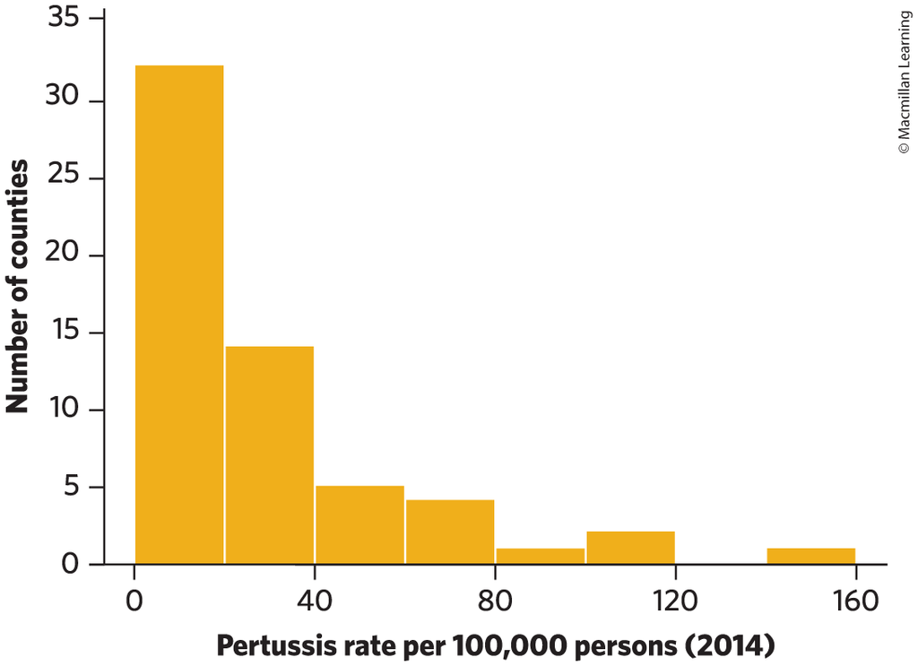

## **Graphs: Histograms**

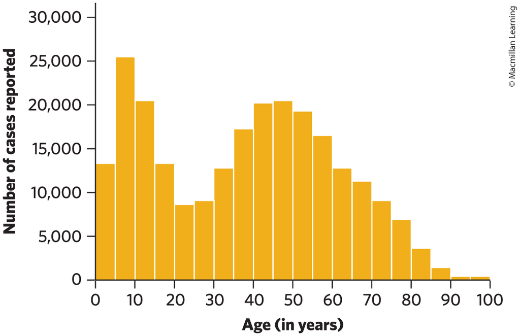

## **Graphs: Histograms**

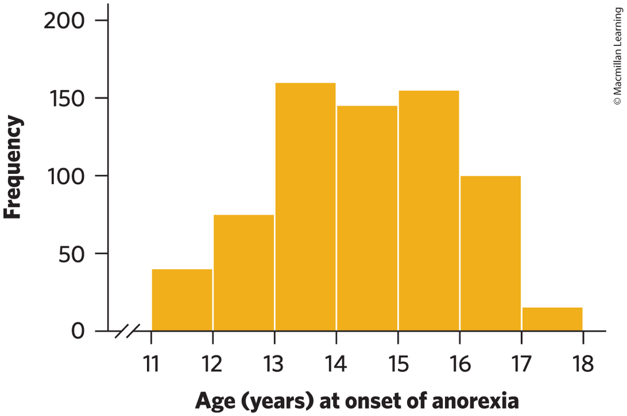

## **Graphs: Histograms (`R` code)**

- We are using the `ggplot2` package for graphing.
  - It will always start with `ggplot()`.
  - We will then layer elements on top.
- R syntax:

```r
dataset_name %>%
  ggplot(aes(x=variable_name)) +
  geom_histogram()
```

## **Graphs: Histograms**

- Let’s look at the histogram of penguin weight (*body_mass_g*):

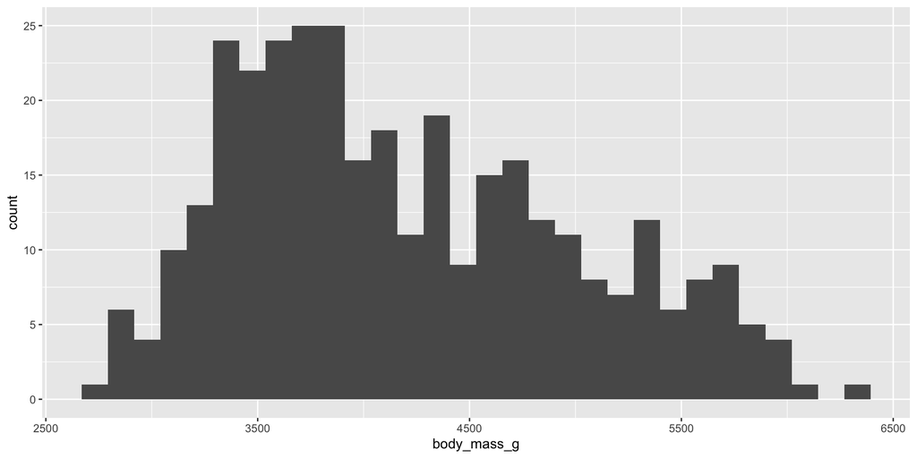

```r
penguins %>%
  ggplot(aes(x=body_mass_g)) +
  geom_histogram()
```

## **Graphs: Histograms**

- Let’s look at the histogram of penguin weight (*body_mass_g*):

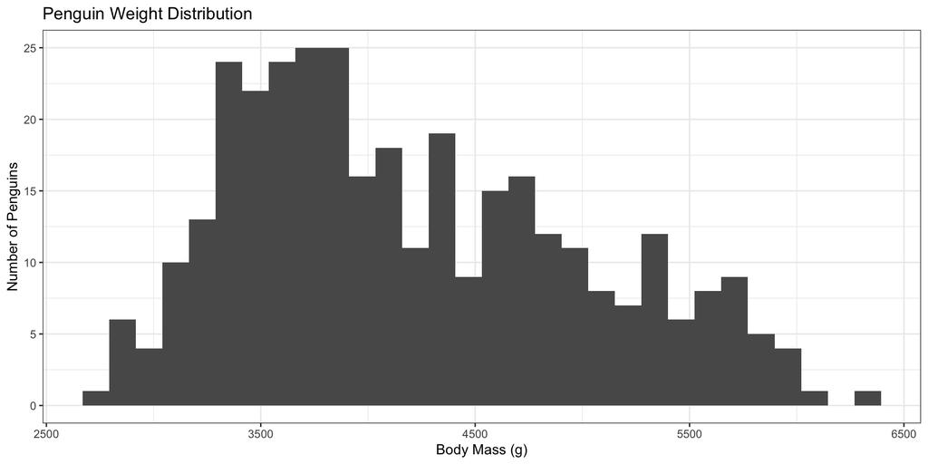

```r
penguins %>%
  ggplot(aes(x=body_mass_g)) +
  geom_histogram() +
  labs(x = "Body Mass (g)",
       y = "Number of Penguins",
       title = "Penguin Weight Distribution") +
  theme_bw()
```

## **Wrap Up**

- Today we reviewed estimation.
- Next week, we will review statistical inference.
  - Confidence intervals
  - Hypothesis testing
- Get to know you quiz - complete with RStudio.
  - .qmd $\to$ Quarto
  - .R $\to$ R script
- Join the Discord server!
  - If you are already a Discord user, this is a friendly reminder that you can change your display name…